# Comparing graph layout engines

Installed figures use static projections. To enable 3D rotation and layout selection, render with `options(grip.vignette.interactive = TRUE)` and **ivue** and **rgl** installed.

## What is compared

This guide shows how to compare multiscale GRIP with layout engines from igraph and graphlayouts using common diagnostics on unweighted graphs. The examples use precomputed fits with the settings described below. They do not compare SGD metric MDS; see Metric MDS for SGD and SMACOF, and Choosing and evaluating for selecting layouts for your data.

## Shared scoring idea

`score.layout()` can score a realized layout from any source. That remains one of the most useful parts of the package, because it lets you compare candidate layouts even when they come from different packages.

```r
score_layout <- function(coords, edges, n,
                         clusters = NULL,
                         edge.crossings = "auto",
                         sample.size.stress = 2000L,
                         sample.size.nonedge = 5000L) {
  score.layout(
    coords = coords,
    edges = edges,
    n = n,
    clusters = clusters,
    sample.size.stress = sample.size.stress,
    sample.size.nonedge = sample.size.nonedge,
    stress.seed = 42L,
    nonedge.seed = 42L,
    edge.crossings = edge.crossings
  )
}
```

For weighted geometry-aware graphs, the package also provides retained-path diagnostics that answer a different question from sampled chord stress:

- `prepare.geodesic.kk()`
- `score.geodesic.kk()`

Planar fits are displayed at z = 0 in interactive 3D viewers. Rotating the view does not change the dimension in which a layout was fitted.

## Track 1: external-package comparisons on unweighted graphs

For this track the comparison remains package-to-package:

- `igraph`
- `graphlayouts`
- `grip`

To keep the article lightweight, the cross-package results are precomputed and bundled as an RDS file. The reproduction script is still:

- `inst/scripts/precompute-vs-alternatives.R`

```r
res.path <- system.file(
  "extdata", "vs_alternatives", "benchmark_results.rds",
  package = "grip"
)
if (!nzchar(res.path)) {
  stop(
    "Precomputed benchmark results not found. ",
    "Run inst/scripts/precompute-vs-alternatives.R first."
  )
}
res <- readRDS(res.path)
```

### Provenance of the saved comparison

The [provenance record](https://github.com/pgajer/grip/blob/main/inst/extdata/vs_alternatives/BENCHMARK_PROVENANCE.md) and [reproduction script](https://github.com/pgajer/grip/blob/main/inst/scripts/precompute-vs-alternatives.R) provide the computation environment, settings and timing boundaries.

The karate graph has **34 vertices and 78 edges**; the 12 by 12 mesh has **144 vertices and 264 edges**. Each table below scores a saved layout with hop-distance stress, scoring seeds 42, 2,000 requested stress pairs, and up to 5,000 sampled nonedges. Exact crossings are enabled for these small graphs. The stress score fits a common scale; it is not the raw stress objective of `metric.mds()`. Preset/tuned rows are labeled separately from ordinary defaults. Keep the results where another method scores better when interpreting the comparison.

### Benchmark 1: Zachary karate club

This is still a useful small-graph sanity check. The graph is small enough that single-scale methods can compete directly.

```r
karate.display <- res$karate$scores[, c(
  "method",
  "sampled.stress",
  "edge.length.cv",
  "edge.crossings",
  "sampled.nonedge.sep.ratio",
  "cluster.separation"
)]

knitr::kable(
  karate.display,
  digits = 4,
  row.names = FALSE,
  caption = "Karate club: precomputed comparison; one seeded layout per method."
)
```

Karate club: precomputed comparison; one seeded layout per method.

| method | sampled.stress | edge.length.cv | edge.crossings | sampled.nonedge.sep.ratio | cluster.separation |
| --- | --- | --- | --- | --- | --- |
| FR (igraph) | 0.2477 | 0.3581 | 68 | 0.3670 | 2.7566 |
| KK (igraph) | 0.2102 | 0.2806 | 73 | 0.3021 | 2.2528 |
| DrL (igraph) | 0.3320 | 0.4680 | 120 | 0.2372 | 1.6584 |
| Stress (graphlayouts) | 0.2075 | 0.2611 | 78 | 0.2747 | 2.2240 |
| grip default | 0.2221 | 0.2941 | 75 | 0.2547 | 2.1364 |
| grip tuned | 0.3254 | 0.2836 | 124 | 0.0570 | 1.7389 |

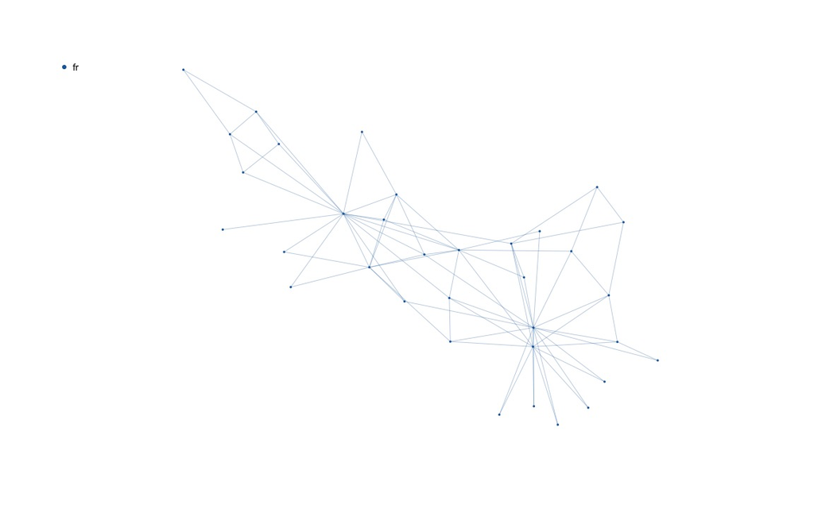

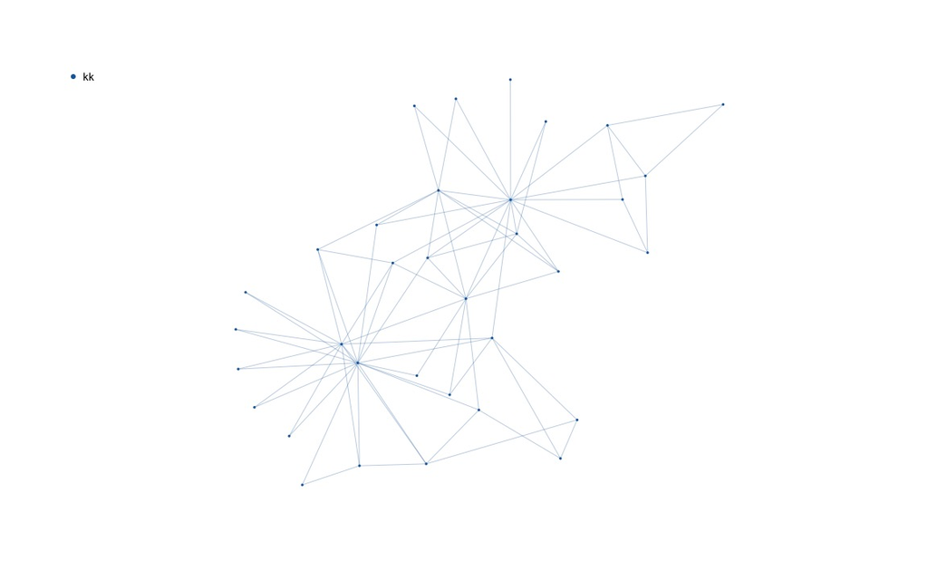

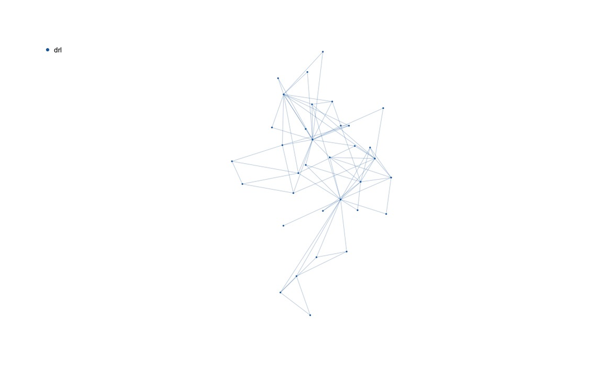

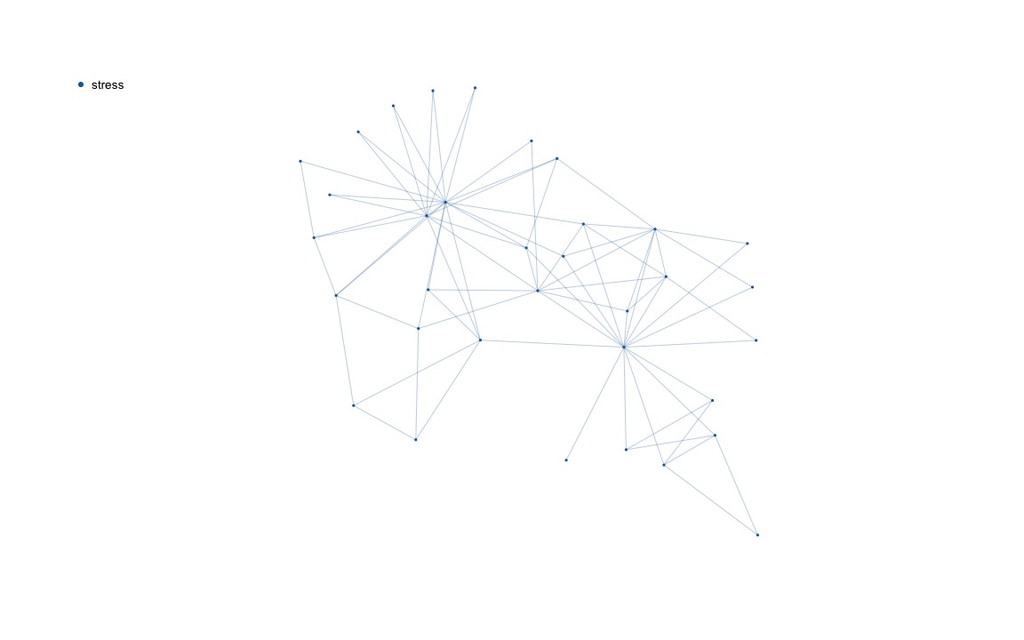

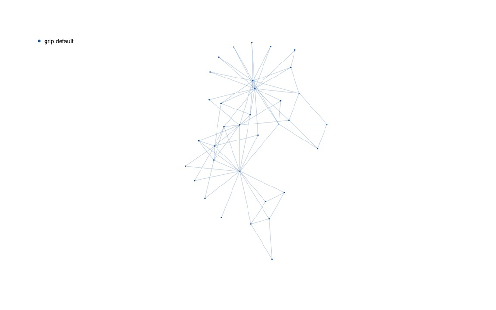

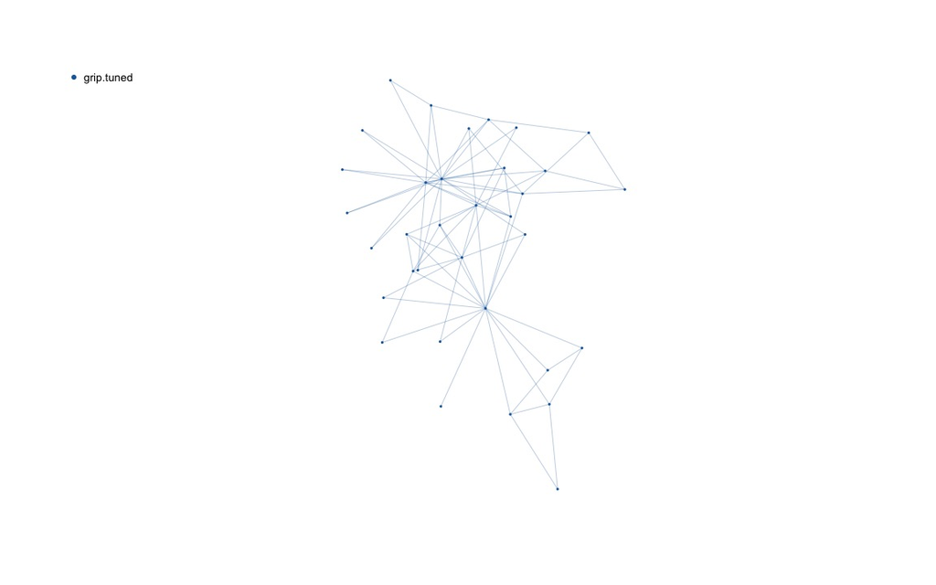

```r
k <- res$karate
comparison.views(k$layouts, k$edges)
```

fr : saved coordinates; 2D fits remain planar. kk : saved coordinates; 2D fits remain planar. drl : saved coordinates; 2D fits remain planar. stress : saved coordinates; 2D fits remain planar. grip.default : saved coordinates; 2D fits remain planar. grip.tuned : saved coordinates; 2D fits remain planar.

On graphs this small, `grip` does not have a special structural advantage. That is an honest result and a useful reminder: multiscale methods are not automatically best on every graph.

### Benchmark 2: 12x12 mesh

Meshes are a good structured topological benchmark because a strong layout should recover an orderly grid with uniform edge lengths and few or no crossings.

```r
mesh.display <- res$mesh$scores[, c(
  "method",
  "sampled.stress",
  "edge.length.cv",
  "edge.crossings",
  "sampled.nonedge.sep.ratio"
)]

knitr::kable(
  mesh.display,
  digits = 4,
  row.names = FALSE,
  caption = "12x12 mesh: precomputed comparison; one seeded layout per method."
)
```

12x12 mesh: precomputed comparison; one seeded layout per method.

| method | sampled.stress | edge.length.cv | edge.crossings | sampled.nonedge.sep.ratio |
| --- | --- | --- | --- | --- |
| FR (igraph) | 0.1159 | 0.1735 | 0 | 0.9731 |
| KK (igraph) | 0.1039 | 0.0135 | 0 | 1.3356 |
| DrL (igraph) | 0.1276 | 0.3580 | 0 | 0.5613 |
| Stress (graphlayouts) | 0.1040 | 0.0138 | 0 | 1.3367 |
| grip default | 0.1089 | 0.0490 | 0 | 1.1589 |
| grip mesh preset | 0.1056 | 0.0497 | 0 | 1.2197 |

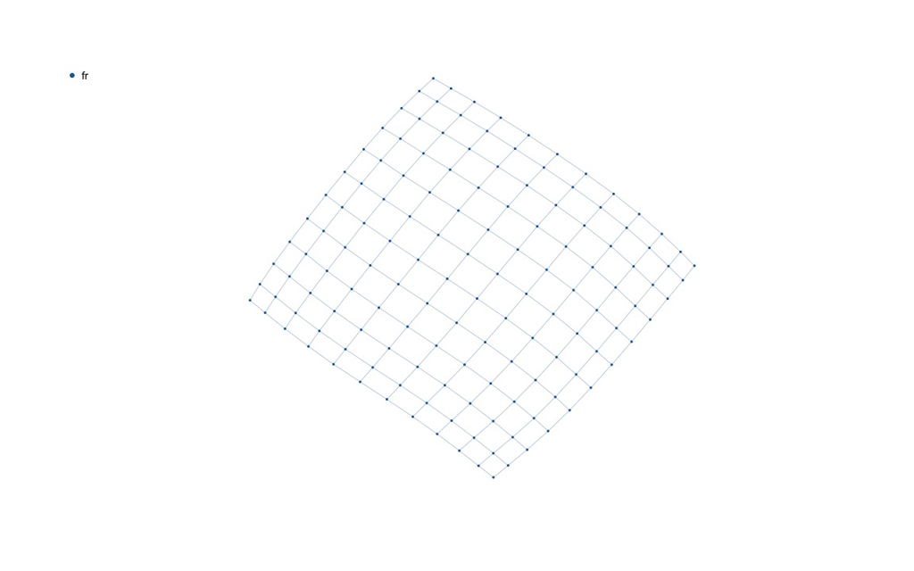

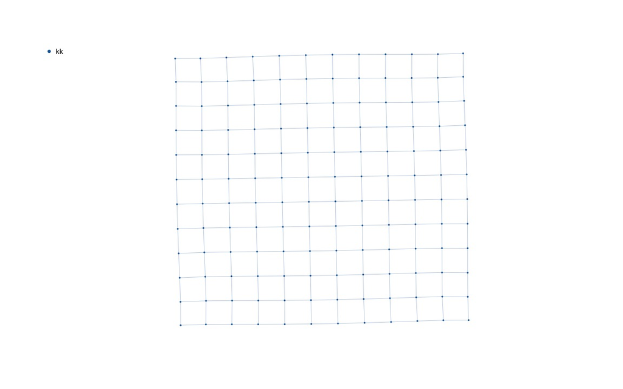

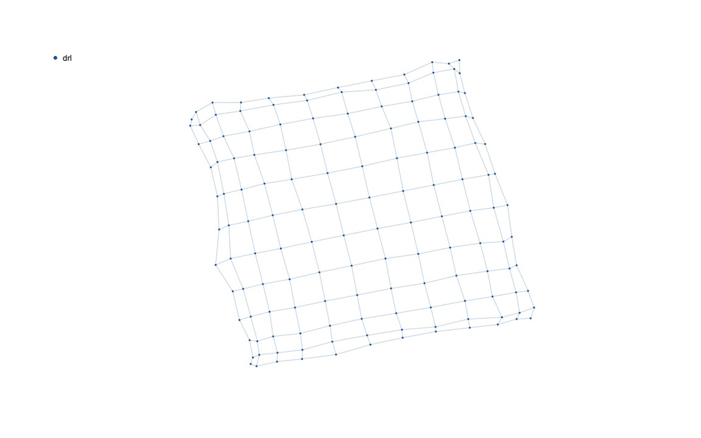

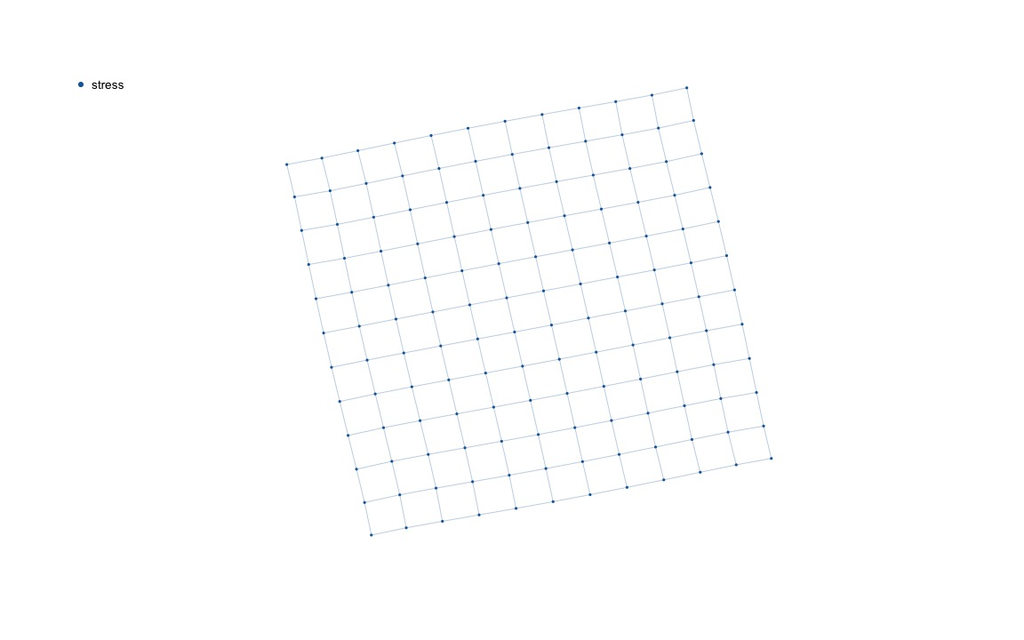

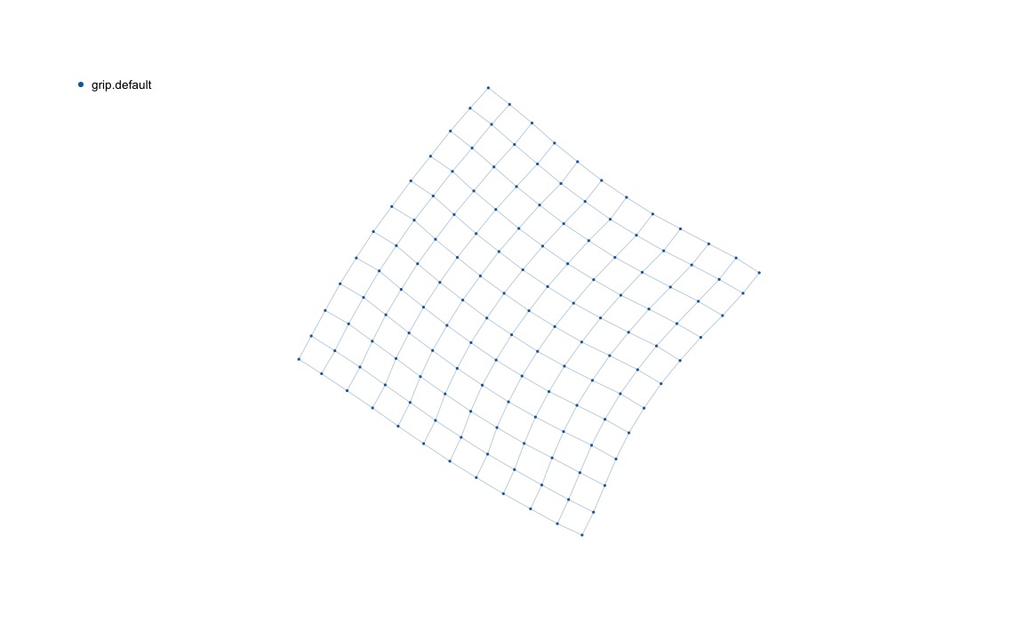

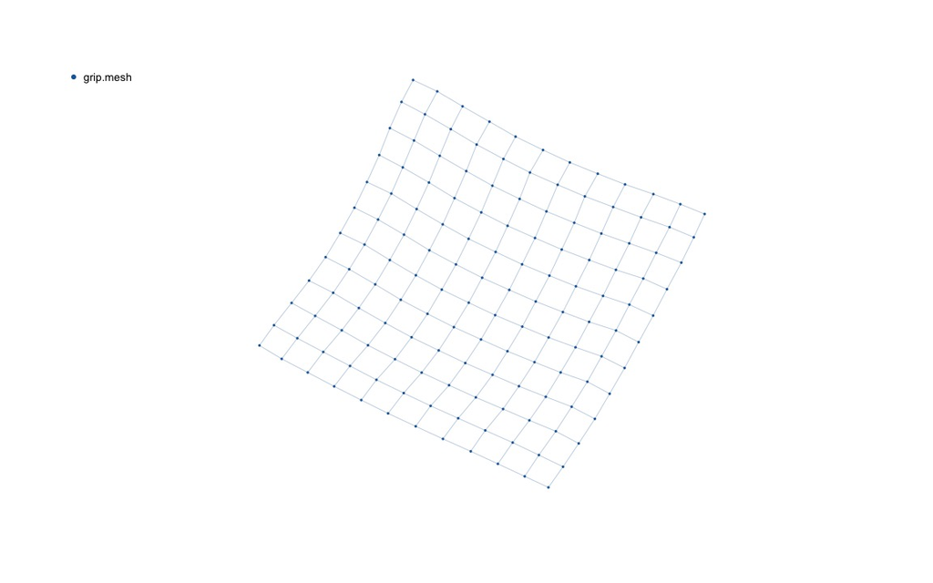

```r
m <- res$mesh
comparison.views(m$layouts, m$edges)
```

fr : saved coordinates; 2D fits remain planar. kk : saved coordinates; 2D fits remain planar. drl : saved coordinates; 2D fits remain planar. stress : saved coordinates; 2D fits remain planar. grip.default : saved coordinates; 2D fits remain planar. grip.mesh : saved coordinates; 2D fits remain planar.

This benchmark shows a different pattern from the karate graph: on a canonical structured family like a mesh, the default GRIP result shows a clean uncrossed layout. The saved `mesh` preset result has slightly lower sampled stress. These are particular seeded results, not an estimate of variation across layout seeds. At the same time, stress and KK remain very strong on a regular lattice.

### Larger graph: saved HMP timing and quality

The same artifact includes an unweighted symmetric-neighbor graph of HMP microbiome samples: **4,391 vertices and 9,067 edges**. PCA-space edge lengths were not supplied to any layout engine. The recorded machine was an Apple M4 Max with 64 GiB memory, macOS/Darwin 25.6.0, and R 4.6.1.

```r
knitr::kable(res$hmp$timing, digits = 3, row.names = FALSE,
  caption = "HMP graph: elapsed seconds for the precomputed layout runs.")
```

HMP graph: elapsed seconds for the precomputed layout runs.

| method | n.runs | elapsed.sec.median | elapsed.sec.iqr |
| --- | --- | --- | --- |
| FR (igraph) | 5 | 0.115 | 0.001 |
| DrL (igraph) | 5 | 2.840 | 0.001 |
| Stress (graphlayouts) | 5 | 24.530 | 0.142 |
| grip default (hop) | 5 | 0.531 | 0.002 |

```r
knitr::kable(res$hmp$scores[, c("method", "sampled.stress", "edge.length.cv")],
  digits = 4, row.names = FALSE,
  caption = "HMP graph: hop-distance quality of the first timed layout per method.")
```

HMP graph: hop-distance quality of the first timed layout per method.

| method | sampled.stress | edge.length.cv |
| --- | --- | --- |
| FR (igraph) | 0.6010 | 0.7438 |
| DrL (igraph) | 0.5122 | 2.5957 |
| Stress (graphlayouts) | 0.1640 | 0.3587 |
| grip default (hop) | 0.2286 | 0.3464 |

The **five timing repeats reset seed 1 before each layout call**. Their medians and interquartile ranges measure timing variation for that seeded setup, not variation across independent stochastic layouts. Timing includes only the layout call; graph construction, garbage collection, and scoring are excluded. Scores use the first repeat, seeds 42, 2,000 stress pairs, and up to 5,000 nonedges; exact crossings are disabled for this graph. These hardware-specific times and single-seed quality results do not establish general speed or accuracy rankings.

### What the unweighted track tells us

The saved external-package benchmark has a limited scope:

- it compares engines on ordinary unweighted graphs,
- it uses a shared scoring function on the same graph for each comparison,
- but it does not answer the geometry-aware weighted-layout question.

That second question needs a different benchmark track.

## Reproducing the external benchmark bundle

Run the comparison recipe with the installed packages and a separate output file:

```r
Sys.setenv(GRIP_VS_ALTERNATIVES_OUTPUT = "benchmark_results.rds")
source(system.file(
  "scripts", "precompute-vs-alternatives.R",
  package = "grip"
))
```